# Team 12 Covid Data Analysis

Varun Chari (117291506)

David Kim (116643764)

Ethan Huegler (117051193)

Htet Kaung Myat Kyaw (117587593)

Kaitlyn Laohoo (115854758)

Anthony Costanza (115761773)

Eisha Ahmed (116630191)

Kyle Weston (117541120)

Yunke Kang (116214209)

11/12/2020

NOTE: All code blocks are folded by default. Access by clicking code button next to the text block. (Or open all at once with the button on the top right)

## Setup

Load libraries

Download and read data.

```r
base_url <- "https://github.com/CSSEGISandData/COVID-19/raw/master/csse_covid_19_data/"

time_series_US_confirmed <- "csse_covid_19_time_series/time_series_covid19_confirmed_US.csv"

time_series_US_confirmed <- paste(base_url, time_series_US_confirmed, sep = "")
time_series_US_confirmed <- read.csv(time_series_US_confirmed)

# legislation data
social_distancing <- read.csv("./data/social_distancing_history_march_to_july_inclusive.csv")

# Get population information about the states
census_url <- "https://www2.census.gov/programs-surveys/popest/datasets/2010-2019/state/detail/SCPRC-EST2019-18+POP-RES.csv"
census <- read.csv(census_url)
census$NAME <- tolower(census$NAME)

# trends data
lockdown_trends_data <- read.csv("./data/lockdown/us.csv")
covid_trends_data <- read.csv("./data/covid/us.csv")
covid19_trends_data <- read.csv("./data/covid19/us.csv")
coronavirus_trends_data <- read.csv("./data/coronavirus/us.csv")
# pop density data
pop_density_data <- read.csv("./data/us_pop_den_by_state_2010.csv")
```

Get the data we *want*. Columns $\left[1,11\right]$ are locale identifiers. Columns $\left[12,\infty\right)$ are dates. The data is more granular than state, it goes down to town/county. We need to fix that.

```r
last_column <- length(time_series_US_confirmed)

# There are 11 columns of data that are not case (mostly related ot location), so the total number of days there is data for will be the length of the dataframe minus 11.
num_days <- last_column - 11

# Data is more granular than state, it goes down to town/county. We need to group them together by state.
by_state <-
  time_series_US_confirmed %>%
  select(c(7, 12:all_of(last_column))) %>%
  group_by(Province_State) %>%
  summarize_at(vars(2:all_of(num_days)), sum)
# %>% adorn_totals('row') #idk what this does

# we are using another library for state names. it expects lower cases names
by_state$Province_State <-
  tolower(by_state$Province_State)

# get the contiguous/continental us states, including D.C.
cont_states <-
  map_data("state")$region %>% unique()
# limit ourselves to continental US
by_state <-
  by_state %>%
  filter(Province_State %in% cont_states) %>%
  dplyr::rename(region = Province_State)

# get the dates in the format given to us: XM.DD.YY (the 'X' is a char literal of unknown purpose)
# Add 1 because we're starting from 2, to get the columns we need
# 2020/1/22 is the first date in the set
col_names <- colnames(by_state)[c(2:all_of(num_days + 1))]
new_col_names <-
  seq(as.Date("2020/1/22"), by = "day", length.out = num_days)
by_state <- by_state %>%
  setNames(new_col_names) %>%
  dplyr::rename(region = "2020-01-22")

# Prepare data for plotting, flatten the data
by_state.long_1 <- pivot_longer(
  by_state,
  cols = c(2:all_of(num_days)),
  names_to = "date",
  values_to = "cases"
)

#####################################################
# Helper functions to generate plots.

# Scales data
scale_data <-
  function(states, cases) {
    data_scaled <-
      data.frame(
        region = vector(),
        date = vector(),
        cases = vector()
      )
    for (state in states) {
      data_scaled <- cases %>%
        filter(region == state) %>%
        mutate(scaled_cases = (cases / filter(census, NAME == state)$POPESTIMATE2019) * 100000) %>%
        merge(data_scaled, all = TRUE)
    }
    return(data_scaled)
  }

# Plots cases
plot_cases <-
  function(cases,
           scaled = FALSE,
           start_date = as.Date("2020-1-22"),
           end_date = Sys.Date() - 1,
           title = "Confirmed Cases vs Time") {
    plot_1 <- cases %>% ggplot(aes(
      x = as.Date(date),
      y = if (scaled) {
        scaled_cases
      } else {
        cases
      },
      group = region,
      color = region
    )) +
      labs(
        title = title,
        x = "Date",
        y = "Number of Cases"
      ) +
      geom_line() +
      # Assuming the data goes up to yesterday.
      scale_x_date(
        limits = c(as.Date("2020-1-22"), as.Date(end_date)),
        date_breaks = "1 month",
        date_labels = "%b"
      ) +
      scale_y_continuous(labels = scales::comma) +
      theme(
        plot.title = element_text(
          color = "black",
          size = 14,
          face = "bold.italic"
        ),
        axis.title.x = element_text(color = "black", size = 10),
        axis.title.y = element_text(color = "black", size = 10),
      )
    return(plot_1)
  }

# This function REQUIRES the plot argument to have name "date"
animate_plot <-
  function(p, w = 750, h = 650, d = 20, ep = 20) {
    if (disable_animation_render) {
      return(p)
    }
    else {
      animation0 <- animate(
        plot = p + transition_reveal(as.Date(date)),
        width = w,
        height = h,
        duration = d,
        end_pause = ep,
        renderer = gifski_renderer()
      )
      return(animation0)
    }
  }

# End helper functions
######################
```

## Question 1: Is “stay at home order” actually effective?

Basic plots lifted from profs code.

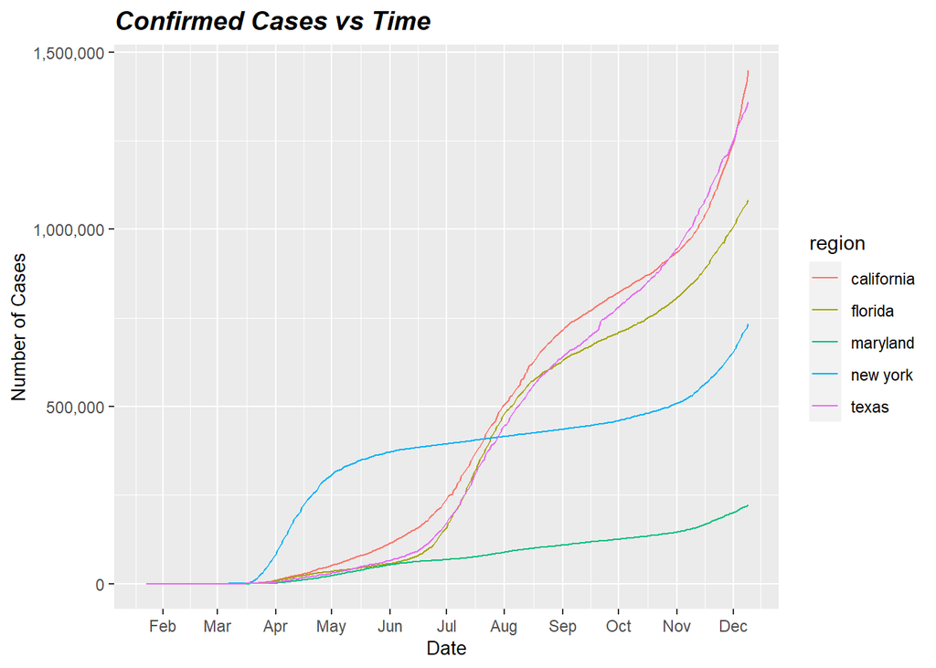

```r
fav_states <-
  c("new york", "florida", "texas", "california", "maryland")
data_fav_states <-
  by_state.long_1 %>% filter(region %in% fav_states)

plot_1 <- data_fav_states %>%
  plot_cases()

# And now the time series as a fancy gif.

animate_plot(plot_1)
```

Scaled plots.

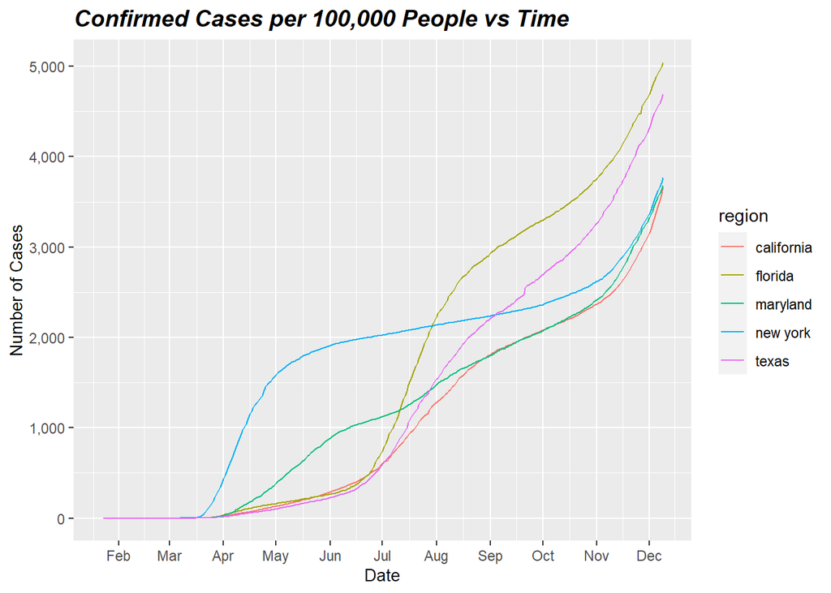

```r
plot_2 <- scale_data(fav_states, data_fav_states) %>%
  plot_cases(scaled = T, title = "Confirmed Cases per 100,000 People vs Time")

animate_plot(plot_2)
```

```r
plot_legislation_overlay <-
  function(state,
           legislation,
           legislationcolor,
           scaled = FALSE) {
    # first letter of state should be capitalized (eg. "Maryland")
    # legislation is numeric - see following
    # 1 = stay at home order, 2 = mandatory quarantine for travelers, 3 = non essential business closures
    # 4 = large gatherings ban, 5 = school closures, 6 = restaurant limits
    legislation_matrix <- c(
      "stay at home order",
      "mandatory quarantine for travelers",
      "non essential business closures",
      "large gatherings ban",
      "school closures",
      "restaurant limits"
    )
    state_legis_data <- social_distancing %>% filter(State == state)
    les_start <- state_legis_data[legislation + 1][[1]]
    les_end <- state_legis_data[legislation + 9][[1]]
    not_enacted <- FALSE
    # check whether date is valid or NA
    if (les_start == "-") {
      # legislation was never enacted
      not_enacted <- TRUE
    } else if (les_end == "-") {
      # legislation was never lifted
      les_start <- as.Date(les_start, format = "%d-%b")
      les_end <- as.Date("2020-07-31")
    } else {
      les_start <- as.Date(les_start, format = "%d-%b")
      les_end <- as.Date(les_end, format = "%d-%b")
    }
    state <- tolower(state)
    state_data <- by_state.long_1 %>% filter(region == state)

    if (scaled) {
      state_data <- scale_data(c(state), state_data)
    }

    plot <- state_data %>%
      plot_cases(
        title = paste(paste(
          paste("COVID case data with", legislation_matrix[legislation], sep = " "),
          "overlayed -",
          sep = " "
        ), state, sep = " "),
        start_date = as.Date("2020-3-01"),
        end_date = as.Date("2020-7-31"),
        scaled = scaled
      )

    if (not_enacted) {
      plot
    } else {
      plot + annotate(
        "rect",
        xmin = les_start,
        xmax = les_end,
        ymin = 0,
        ymax = Inf,
        alpha = 0.2,
        fill = legislationcolor
      )
    }
  }
```

```r
# This function returns slope and intercept of linear regression between X = days passed from "from" argument, Y = scaled covid cases
get_slope <-
  function(state, from, until) {
    from <- as.Date(from)
    until <- as.Date(until)
    state_data <- by_state.long_1 %>% filter(region == state)
    state_data <- scale_data(c(state), state_data)
    state_data <- state_data %>% filter(as.Date(date) > as.Date(from))
    state_data <- state_data %>% filter(as.Date(date) < as.Date(until))
    regres <- lm(state_data$scaled_cases ~ as.integer(as.Date(state_data$date) - as.Date(from)))
    intercept <- regres[[1]][[1]]
    slope <- regres[[1]][[2]]
    return(c(slope, intercept))
  }
```

### Analysis

```r
states <- c("New Jersey", "Rhode Island", "Massachusetts", "Connecticut", "Maryland", "Delaware", "New York")
saa_order <- c("Yes", "Yes", "No", "Yes", "Yes", "Yes", "Yes")
slopes <- c()
for (state_lower in tolower(states)) {
  slopes <- append(slopes, get_slope(state = state_lower, from = "2020-04-01", until = "2020-05-01")[1])
}
df <- data.frame(states, saa_order, slopes)
kable(df, col.names = c("State", "Stay at Home Enacted?", "Avg. April new positives per day"))
```

| State | Stay at Home Enacted? | Avg. April new positives per day |
| --- | --- | --- |
| New Jersey | Yes | 37.85710 |
| Rhode Island | Yes | 28.81945 |
| Massachusetts | No | 29.25928 |
| Connecticut | Yes | 25.16744 |
| Maryland | Yes | 11.62734 |
| Delaware | Yes | 16.09194 |
| New York | Yes | 39.04711 |

Avg. slope of states in this table with “stay at home order”:

- 26.435

Avg. slope of states in this table without “stay at home order”:

- 29.259

Conclusion: Analyzing the above table, the stay at home order has shown to be effective for states with high population density.

Possible Problem: only 1 state (massachusetts) in this group did not impose stay at home order

Note: No outliers exist in the slope set

```r
states <- c("Florida", "California", "Kentucky", "Texas", "Iowa", "Nebraska")
saa_order <- c("Yes", "Yes", "No", "Yes", "No", "No")
slopes <- c()
for (state_lower in tolower(states)) {
  slopes <- append(slopes, get_slope(state = state_lower, from = "2020-04-01", until = "2020-05-01")[1])
}
df <- data.frame(states, saa_order, slopes)
kable(df, col.names = c("State", "Stay at Home Enacted?", "Avg. April new positives per day"))
```

| State | Stay at Home Enacted? | Avg. April new positives per day |
| --- | --- | --- |
| Florida | Yes | 4.186631 |
| California | Yes | 3.518048 |
| Kentucky | No | 3.302090 |
| Texas | Yes | 2.871515 |
| Iowa | No | 7.124337 |
| Nebraska | No | 6.767336 |

Avg. slope of states in this table with “stay at home order”

- 3.525

Avg. slope of states in this table without “stay at home order”

- 5.731

Conclusion: stay at home order somewhat effective for states with low pop. density

Note: no outliers exist in this slope set

Possible improvements: Add statistical tests with p-values to support this claim

## Question 2: Does population density and the speed of spread (slope for the first month) correlate?

```r
state_names <- c()
popdens <- c()
sp_of_sprd <- c()
for (state_name in pop_density_data$State) {
  # skip these two states because no one lives there anyways and they are giving errors
  # if you're from these two states, I'm sorry no offense
  if (state_name == "Hawaii" || state_name == "Alaska") {
    next
  }
  # remove outliers of spread speed (yields better result when outlier not removed)
  # if (state_name == "New York" || state_name == "New Jersey"|| state_name == "Massachusetts"|| state_name == "Rhodes Island"|| state_name == "Connecticut") { next }
  density <- as.numeric((pop_density_data %>% filter(State == state_name))$People.per.Square.Mile)
  speed <- get_slope(tolower(state_name), "2020-04-01", "2020-05-01")
  state_names <- append(state_names, state_name)
  popdens <- append(popdens, density)
  sp_of_sprd <- append(sp_of_sprd, speed[1])
}
```

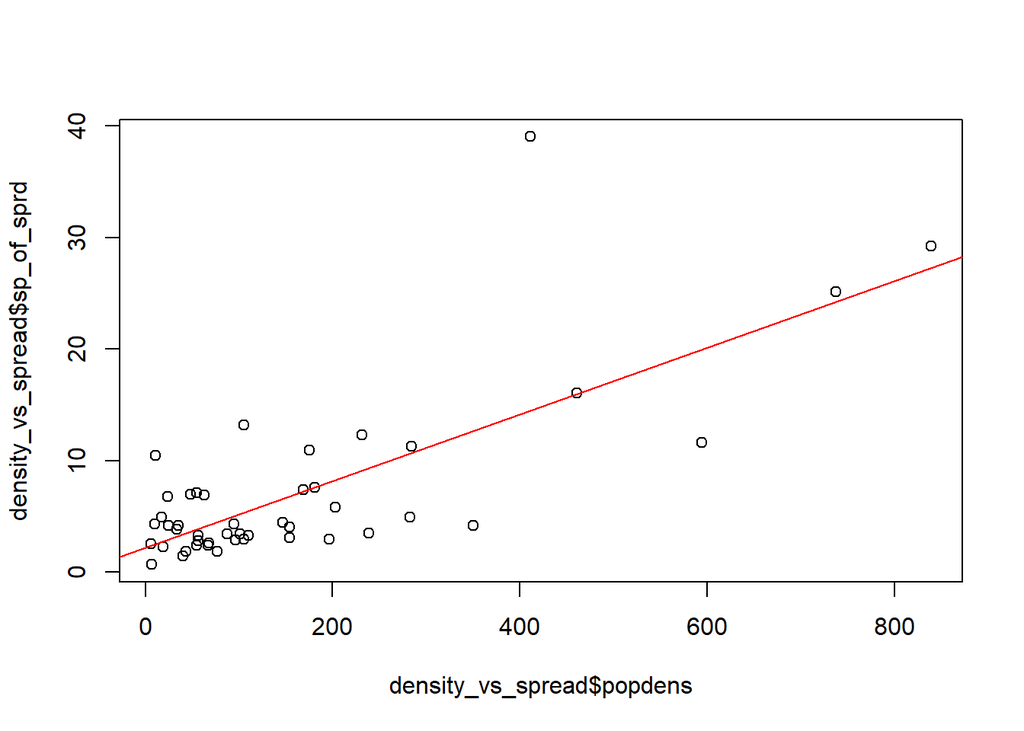

```r
density_vs_spread <- data.frame(state_names, popdens, sp_of_sprd)
regres <- lm(density_vs_spread$sp_of_sprd ~ density_vs_spread$popdens)
plot(density_vs_spread$popdens, density_vs_spread$sp_of_sprd)
abline(a = regres[1], regres[2], col = "red")
```

```r
summary(regres)$r.squared
```

```
## [1] 0.5531174
```

This R code gets spread speed (slope) for the first month of covid (april) for each state and plots it against the population density.

### Analysis

Possible improvements: Use the population density data that is more detailed? Right now the code is using state-level but we can maybe use city-level.

## Question 3: How does Google Trends search term and covid case data correlate?

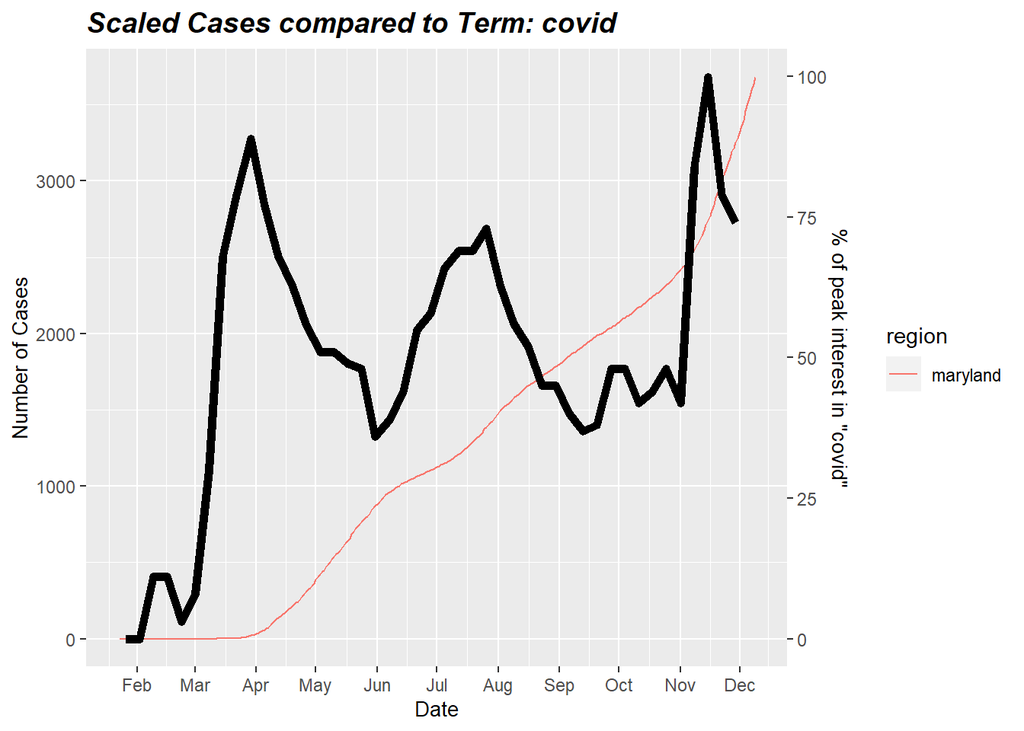

```r
plot_trends_data <- function(state, cases = data_fav_states, term) {
  state <- tolower(state)
  trends_data <-
    read.csv(paste(sep = "/", ".", "data", term, paste(sep = "", state, ".csv")))

  # Takes a path to the trends data and what states to plot. Defaults to fav_states if none chosen
  scaled_data <-
    scale_data(state, cases) %>% filter(region == state)

  trends_data <- mutate(trends_data, date = Week, Week = NULL)

  scale_factor <-
    max(scaled_data$scaled_cases) / max(trends_data[1])

  plot <- scaled_data %>%
    plot_cases(
      scaled = T,
      title = paste("Scaled Cases compared to Term:", term)
    ) +
    geom_line(
      data = trends_data,
      inherit.aes = FALSE,
      aes(
        x = as.Date(date, "%Y-%m-%d"),
        y = trends_data[, 1] * scale_factor
      ),
      size = 2
    ) +
    scale_y_continuous(sec.axis = sec_axis(~ . / (max(
      scaled_data$scaled_cases
    ) / 100), name = paste(sep = "", "% of peak interest in \"", term, "\"")))

  return(plot)
}

# plot_trends_data("california", term = "covid")
plot_trends_data("maryland", term = "covid")
```

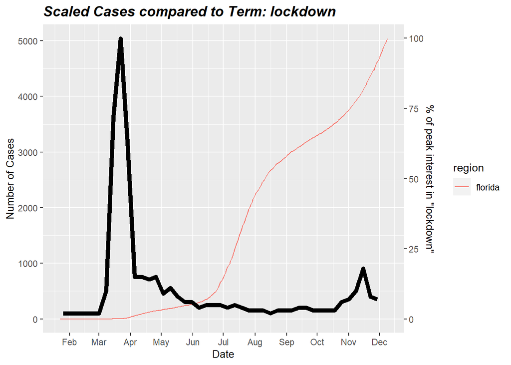

```r
# plot_trends_data("new york", term = "covid")
# plot_trends_data("texas", term = "covid")
# plot_trends_data("florida", term = "covid")

# plot_trends_data("california", term = "lockdown")
# plot_trends_data("maryland", term = "lockdown")
# plot_trends_data("new york", term = "lockdown")
# plot_trends_data("texas", term = "lockdown")
plot_trends_data("florida", term = "lockdown")
```

### Analysis Term “lockdown”

Conclusion: The spikes in the search term “lockdown” appear to correlate with dates that stay-at-home orders were put into place or had recently gone into effect.